# HW 3: Stylized Asset Return Facts

Sam

2025-02-08

# Análisis de Hechos Estilizados

## Preparación de datos

Primero se descarga una lista de precios de cierre ajustados de Amazon, Tesla y Apple desde yahoo finance con sus apropiados tickers.

```r
library(quantmod)
datos <- new.env()
claves <- c("AMZN", "TSLA", "AAPL")
getSymbols(claves, env = datos)
```

```
## [1] "AMZN" "TSLA" "AAPL"
```

```r
precio <- cbind(datos[["AMZN"]][,6], datos[["TSLA"]][,6], datos[["AAPL"]][,6])
colnames(precio) <- claves
```

## Hecho Estilizado 1: Precio

Veamos los datos que acabamos de descargar:

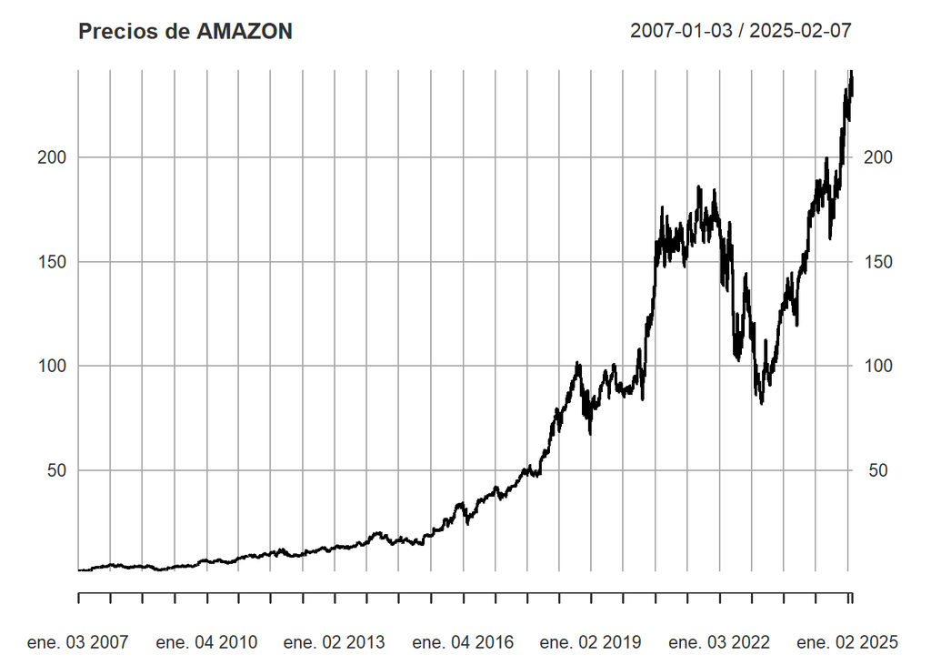

```r
plot(precio[, "AMZN"], main = 'Precios de AMAZON')
```

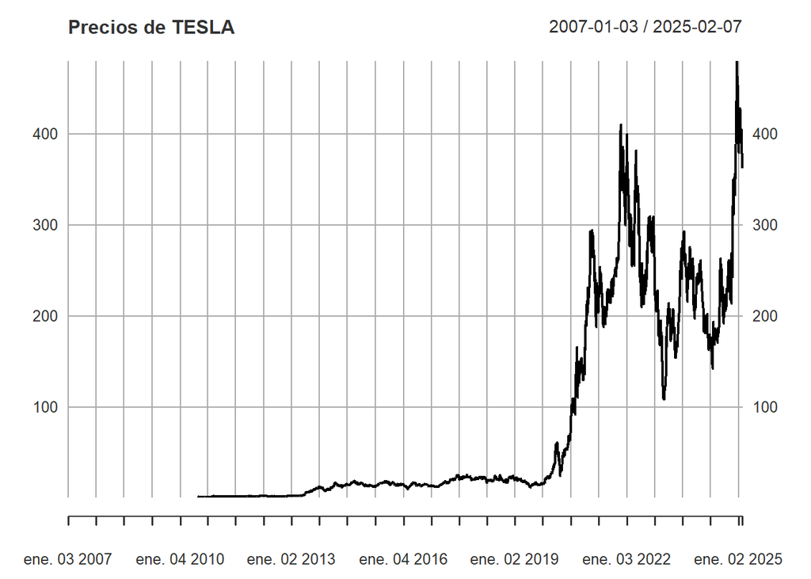

```r
plot(precio[, "TSLA"], main = 'Precios de TESLA')
```

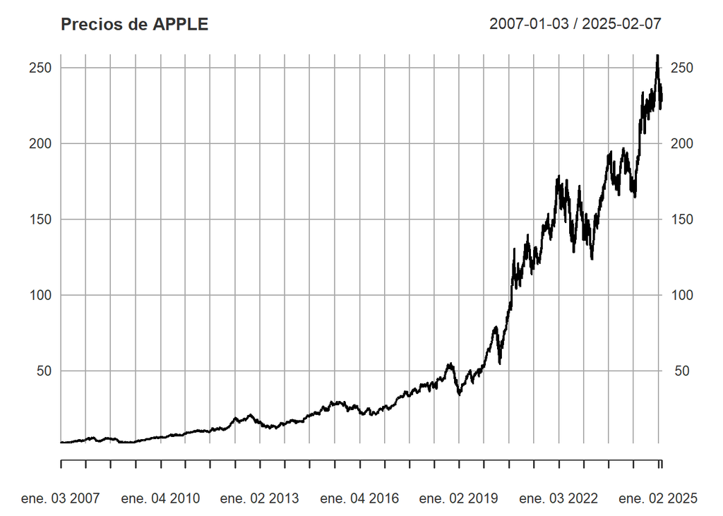

```r
plot(precio[, "AAPL"], main = 'Precios de APPLE')
```

El comportamiento del precio en estas gráficas sugieren que las 3 seguen una caminata aleatoria porque los cambios son impredecibles y dependen principalmente del valor anterior más un componente aleatorio del mercado. Podemos ver que el precio de los 3 casos tiende a crecer con el tiempo, pero poseé variaciones erráticas características de una caminata aleatoria, por lo que podemos decir con certeza que sí cumplen el primer hecho estilizado: ‘Los precios siguen un comportamiento de caminata aleatoria’.

## Hecho Estilizado 2: Rendimiento

Ahora se calcula el rendimiento de los precios y se grafíca un histograma de este con una línea de densidad por encima para tener una mejor observación de su comportamiento:

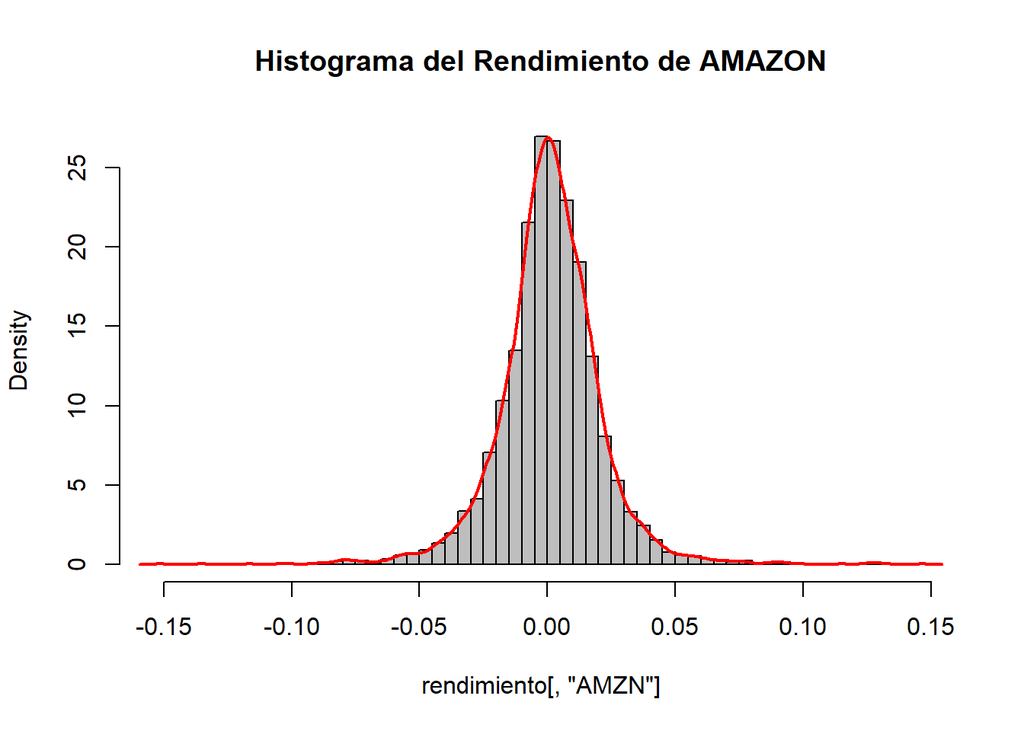

```r
rendimiento <- na.omit(diff(log(precio)))

hist(rendimiento[, 'AMZN'], n=100, col='gray',
     main='Histograma del Rendimiento de AMAZON', prob = TRUE)
lines(density(rendimiento[, 'AMZN']), col = 'red', lwd = 2)
```

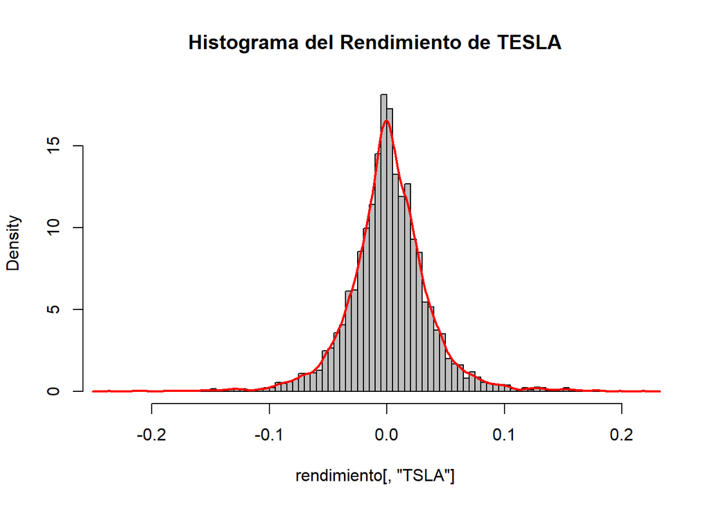

```r
hist(rendimiento[, 'TSLA'], n=100, col='gray',
     main='Histograma del Rendimiento de TESLA', prob = TRUE)
lines(density(rendimiento[, 'TSLA']), col = 'red', lwd = 2)
```

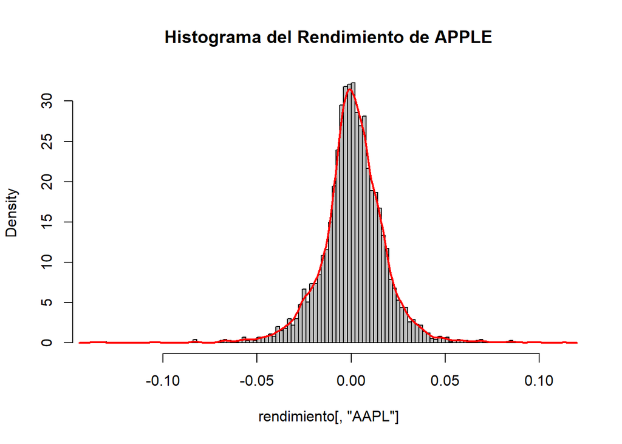

```r
hist(rendimiento[, 'AAPL'], n=100, col='gray',
     main='Histograma del Rendimiento de APPLE', prob = TRUE)
lines(density(rendimiento[, 'AAPL']), col = 'red', lwd = 2)
```

## Hecho Estilizado 3: Volatilidad

Empleamos bandas de Bollinger para visualizar la volatilidad de los precios:

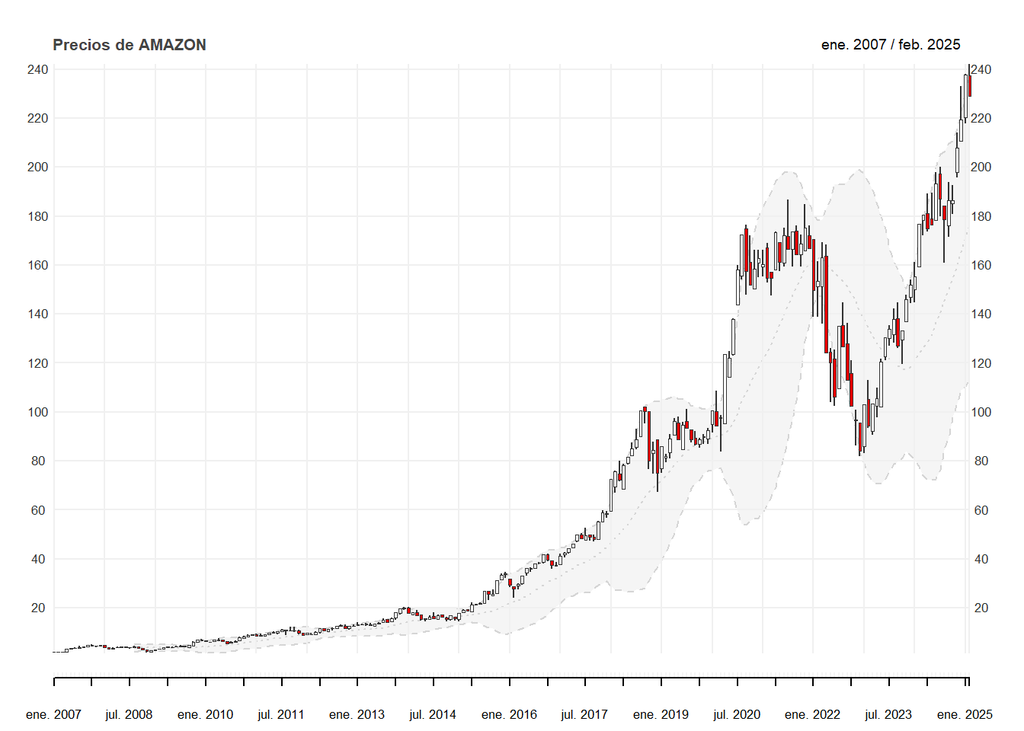

```r
chart_Series(to.monthly(precio[, "AMZN"]),
             name = "Precios de AMAZON", TA = 'add_BBands()')
```

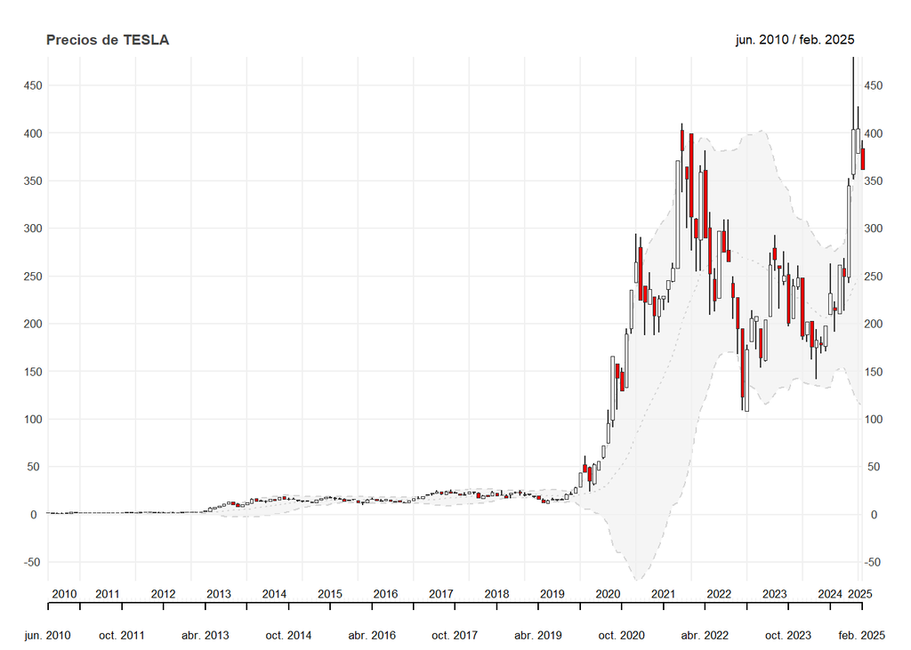

```r
chart_Series(to.monthly(precio[, "TSLA"]),
             name = "Precios de TESLA", TA = 'add_BBands()')
```

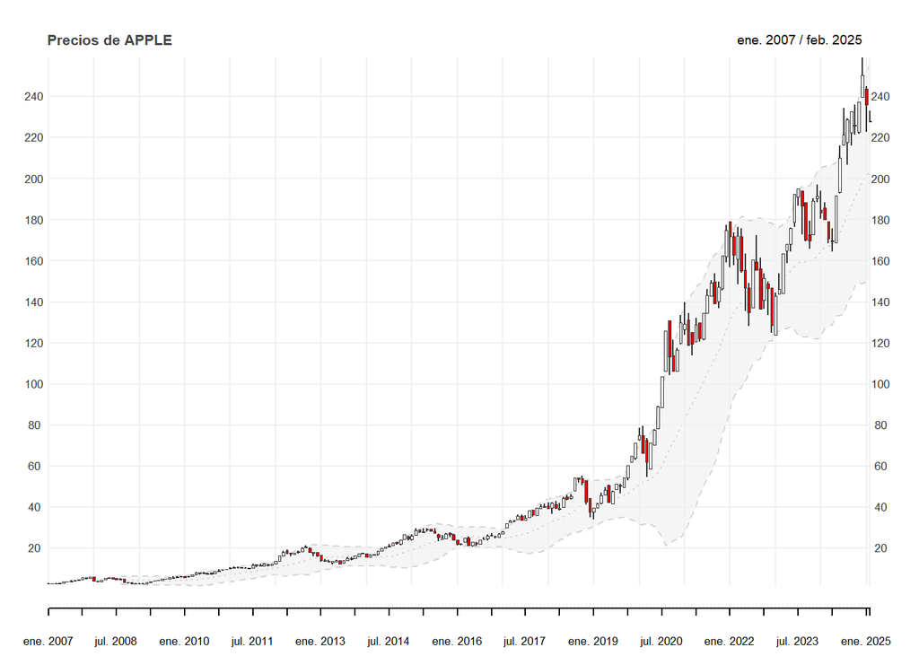

```r
chart_Series(to.monthly(precio[, "AAPL"]),
             name = "Precios de APPLE", TA = 'add_BBands()')
```

Estos gráficos son evidencia de la presencia de volatilidad agrupada, ya que muestran periodos en los que los movimientos del precio son amplios y sostenidos, seguidos de fases más tranquilas. Esto indica que los choques de volatilidad ni son constantes, ni ocurren de manera aislada, sino en clusters, las cuales son propiedades fundamentales en el 3er hecho estilizado.

## Hecho Estilizado 4: Colas pesadas

Este último hecho se puede analizar de 2 maneras distintas:

1. Observando el ruido blanco
2. Observando el histograma del rendimiento previamente hecho

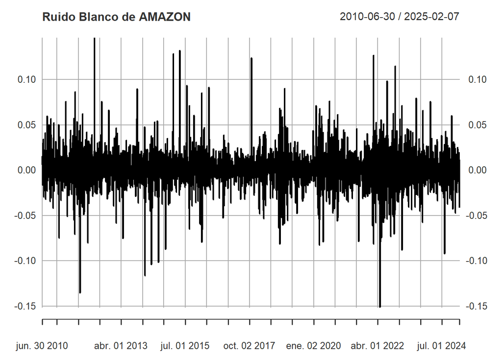

```r
plot(rendimiento[, 'AMZN'], main = 'Ruido Blanco de AMAZON')
```

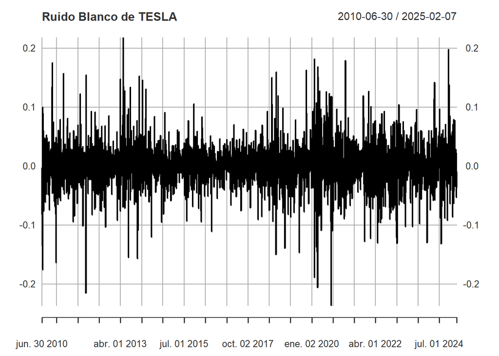

```r
plot(rendimiento[, 'TSLA'], main = 'Ruido Blanco de TESLA')
```

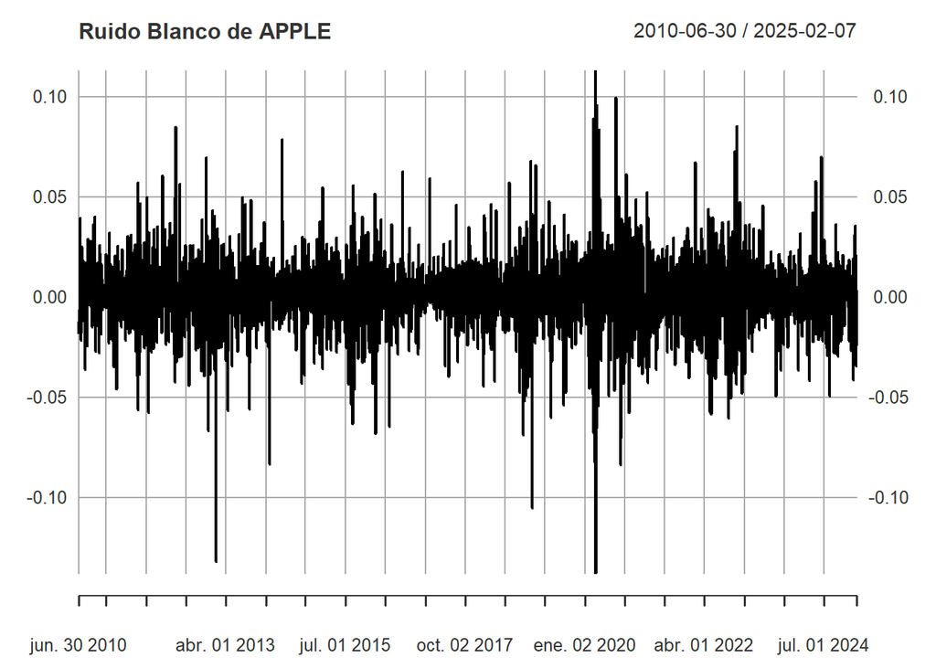

```r
plot(rendimiento[, 'AAPL'], main = 'Ruido Blanco de APPLE')
```

Ambos tipos de gráficos dan evidencia que los rendimientos financieros poseen leptocurtosis. Tanto en el ruido blanco como en el histograma observamos una gran cantidad de datos alrededor de la media 0, y muy pocos en los extremos, ocasionando que dicha distribución tenga colas pesadas y contraste con una distribución normal, indicando que los eventos extremos son más recurrentes de lo que uno pensaría. Dichas propiedades son clave del 4to y último hecho estilizado a comprobar.

## Conclusiones:

El análisis de los 4 hechos estilizados del comportamiento de los precios y rendimientos de activos financieros nos permite comprender mejor la naturaleza de los mercados y los desafíos que representan para la gestión del riesgo y modelo de ellos. Estos son fundamentales porque reflejan la realidad del comportamiento de los activos y nos dejan ver las limitaciones de los modelos basados en supuestos de normalidad.

Reconocer estos hechos estilizados es clave para construir modelos de riesgo y pronóstico más sólidos y efectivos, pues ignorar estos patrones y propiedades pueden llevar a una subestimación del riesgo real en los mercados; mientras que integrarlos en los análisis permite tomar decisiones más informadas y estrategias de inversión más convenientes.